# LAB 47 (MD)

AnaGSanjuanM

2023-03-18

————————–LABORATORIO 47——————————–

Hecho con gusto por Carla Carolina Pérez Hernández (UAEH)

V3

—————Alumna: Ana Grisel Sanjuan Merida————————–

LABORATORIO - Gráficos en R con ggplot2 para Ciencia de Datos

Graficas de barras en R

Instalanr paquete con los datos

install.packages(“gapminder”)

install.packages(“ggplot2”)

Cargar libreria ggplot2 y gapminder

```r
library(ggplot2)
library(gapminder)
```

Cargar y visualizar datos al entorno

```r
data("gapminder")
```

Filtrando por año 2007

Se crea objeto llamado gapminder2007

Se aprecia el data en el environment

```r
gapminder2007 <- gapminder[gapminder$year == '2007', ]
```

Gráfica de barras

Se extraen datos de gapminder2007

La gráfica tendrá diversos elementos estéticos

Variable X será un factor de conteo de cuántos países incluye cada continente

El gráfico será de barras

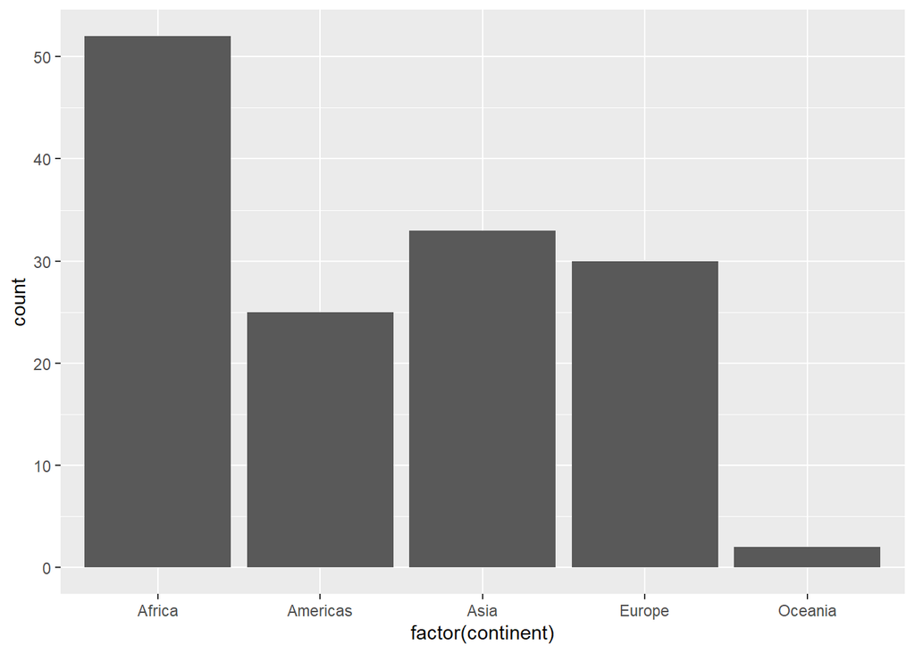

```r
ggplot(data=gapminder2007,
       mappin = aes(x = factor(continent)))+
  geom_bar()
```

Se extraen datos de gapminder2007

La gráfica tendrá diversos elementos estéticos

Variable X será un factor de conteo de cuántos países incluye cada continente

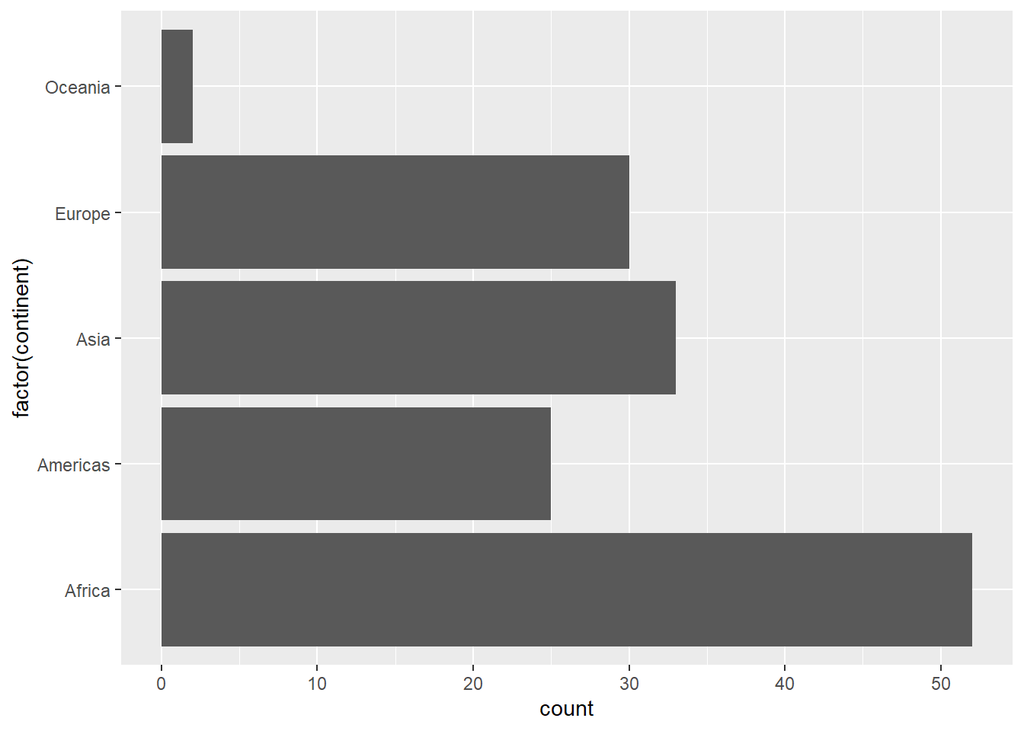

```r
ggplot(data=gapminder2007,
       mappin = aes(x = factor(continent)))+
  geom_bar() +
  coord_flip()
```

Creando etiqueta para expectativa de vida a través de variable categórica

Se extraen datos de gapminder2007 fijando la expectativa de vida

La etiqueta tendrá condicionante: como input gapminder2007

Sí dentro de la variable hay un conteo menor a cincuenta, la categoría será “poca”

Sí dentro de la variable hay un conteo menor a setenta, la categoría será “media”

Sí dentro de la varibales no se cumple con ninguna de las dos condicionantes, la categoría será “alta”

Se visualiza en el environment

```r
gapminder2007$lifeExp_label <- ifelse(
  gapminder2007$lifeExp < 50,
  "poca",
  ifelse(gapminder2007$lifeExp < 70,
         "media" ,
         "alta"))
```

Guardando grafica en variable

Primero generamos objeto p

De los datos de gapminder2007

Los elementos estéticos son que en la X será un factor de conteo de los continente

Con un rellenado con base en la etiqueta lifeExp_label

```r
p <- ggplot(data=gapminder2007,
            mapping = aes(x = factor(continent),
                          fill = lifeExp_label))
```

Stacked bar chart (apilada)

Del objeto p agregamos una capa: geom_bar

Es una gráfica apilada con base en la expectativa de vida

Con relación al conteo de los países en los continentes que revelan nivel alto, medio y poca de lifeExp

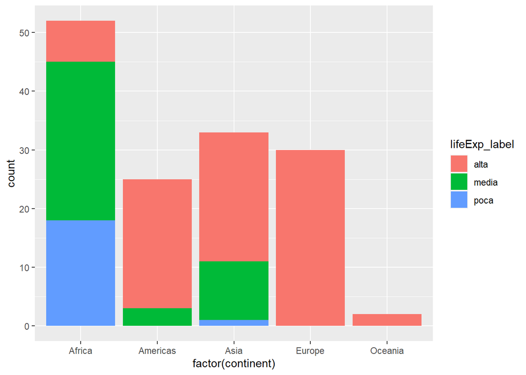

```r
p + geom_bar(position = "stack", stat = "count")
```

Dodge bar chart (separada)

Del objeto p agregamos una capa: geom_bar

Es una gráfica separada con base en la expectativa de vida

Con relación al conteo de los países en los continentes que revelan nivel alto, medio y poca de lifeExp

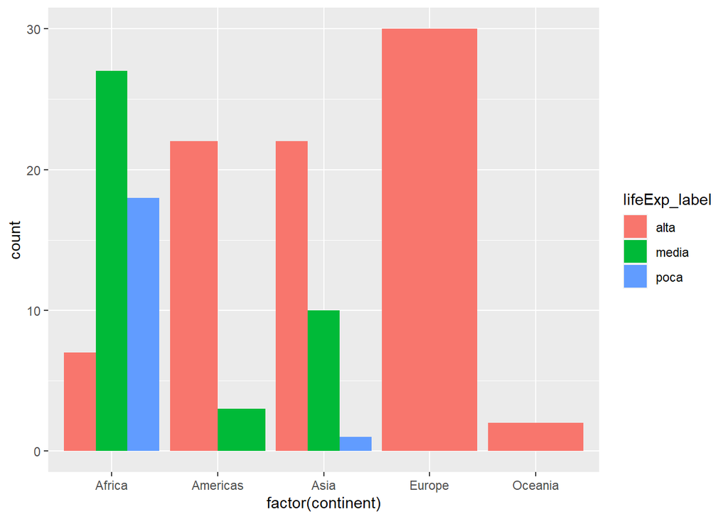

```r
p + geom_bar(position = "dodge", stat = "count")
```

LLENA 100% + percent barchart

Del objeto p agregamos una capa: geom_bar

Es una gráfica fill (del 100%) con base en la expectativa de vida

Con relación al conteo de los países en los continentes que revelan nivel alto, medio y poca de lifeExp

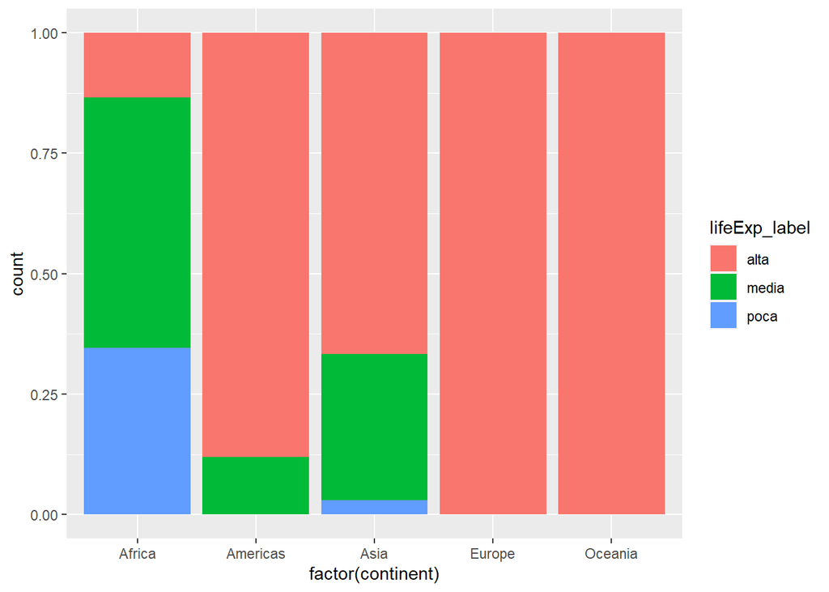

```r
p + geom_bar(position = "fill", stat = "count")
```

——————FIN LABORATORIO 47————————